# Grundbildungspfade

Zielgruppenkompetenzen: PIAAC Bericht

Nate Breznau

Die Daten stammen aus den ersten beiden Zyklen von PIAAC. Die Dateien zum Importieren und Bereinigen der Daten liegen im Ordner /PIAAC_VET_Basics.

A2_Q04aDEX “Und wie ist es mit der deutschen Sprache: Responses: 01: Wie gut sprechen Sie Deutsch? | 02: Wie gut schreiben Sie auf Deutsch? | 03: Wie gut lesen Sie auf Deutsch?” ist nicht im PUF

## Setup

```r
packages <- c('tidyverse',
              'readr',
              'here',
              'ggplot2')

pacman::p_load(packages, character.only = T)

# function for weighted mean
weighted_mean <- function(var, weights) {
  sum(var * weights, na.rm = TRUE) / sum(weights[!is.na(var)], na.rm = TRUE)
}

colors3 <- c("#3b528b", "#21918c", "#5ec962")
```

## Data

```r
df <- read_csv(here("Data", "piaac_de.csv"))
df2 <- read_csv(here("Data", "piaac_de_2.csv"))
```

## Deutsch als Zweitsprache, gering Qualifizierter

Einwanderer mit ISCED 1/2, Deutsch als Zweitsprache.

**Zielgruppe für GrundBildungsBrücken Hamburg (GBHH)**

### Group 01

### Skills

Ein Vergleich der Kompetenzen von Einwanderern mit Deutsch als Zweitsprache und gering formaler Bildung (ISCED 1 oder 2, keine oder nur geringe Sekundarschulbildung) zeigt, dass die Rechen- und Lesekompetenz seit 2012 zurückgegangen ist, insbesondere die Lesekompetenz. Während ähnlich gebildete gebürtige Deutsche mit Deutsch als Muttersprache viel höhere Kompetenzen aufweisen und diese seit 2012 im Durchschnitt gestiegen sind - sie liegen nicht so weit hinter denen mit höherer formaler Bildung.

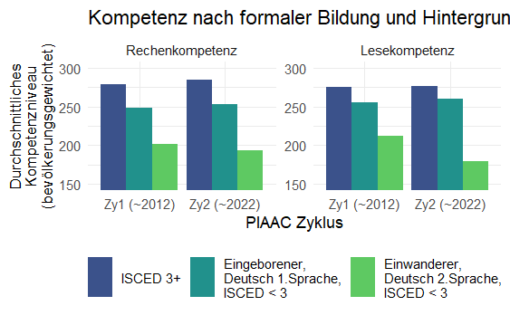

## Gering lit. Erwachsene, die i.d. Pflegehilfe eine Ausbildung machen möchten

**Grundbildung in der Pflege stärken (GriPs)**

Nicht genau identifizierbar. Wir können nur Leute die gerade in Bildung oder Weiterbildung sind, und ,Gesundheit’ studieren.

## Langzeitabeitslose, gering lit.

**Berliner Kooperations-verbund Arbeits-orientierte GB (BerKo)**

Wir können Arbeitslosigkeit seit 5 Jahren identifizieren, mehr nicht. Und d.h. 3 bis 5 von den letzen 5 Jahren Arbeitslos (Antwortkategorie 4). Und das ist nur in Zyklus 2 vom PIAAC (neue Frage)

### Group 03

```r
g03cat5 <- df2 %>%
  subset(!is.na(group_03)) %>%
  group_by(group_03, reading_category) %>%
  summarise(weighted_count = sum(SPFWT0, na.rm = TRUE), .groups = "drop") %>%
  group_by(group_03) %>%
  mutate(percent = weighted_count / sum(weighted_count) * 100)
```

[output not shown]

### Distribution

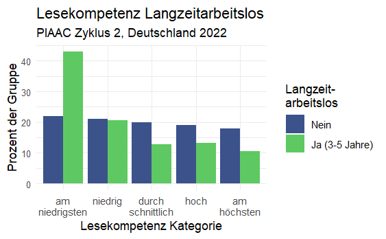

```r
ggplot(g03cat5, aes(x = skill_reading_cat5, y = percent, fill = as.factor(group_03))) +
  geom_bar(stat = "identity", position = "dodge") +
  scale_fill_manual(values = c(colors3[1], colors3[3]), labels = c("Nein", "Ja (3-5 Jahre)")) +
  labs(title = "Lesekompetenz Langzeitarbeitslos",
       subtitle = "PIAAC Zyklus 2, Deutschland 2022",
       x = "Lesekompetenz Kategorie",
       y = "Prozent der Gruppe",
       fill = "Langzeit-\narbeitslos") +
  theme_minimal() +
  theme(axis.text.y = element_text(size = 8))
```

```r
NA
NA
```